# Bike rentals in DC

## Data

Source: [UCI Machine Learning Repository - Bike Sharing Dataset](https://archive.ics.uci.edu/dataset/275/bike+sharing+dataset)

The data include daily bike rental counts (by members and casual users) of Capital Bikeshare in Washington, DC in 2011 and 2012 as well as weather information on these days.

```r
library(tidyverse)
library(tidymodels)
```

### Reading the data

The data is loaded and the variables `season`, `yr`, `holiday` and `weathersit` is converted into factor type.

```r
dcbikeshare <- read_csv("data/dcbikeshare.csv") |>
  mutate(
    season = factor(season,
                    levels = c(2,3,4,1),
                    labels = c("spring","summer","fall","winter")),
    holiday = factor(holiday,
                     levels = 0:1,
                     labels = c("no", "yes")),
    workingday = factor(workingday,
                        levels = 0:1,
                        labels = c("no", "yes")),
    yr = factor(yr,
                level = 0:1,
                labels = 2011:2012),
    weathersit = factor(weathersit,
                        levels = 1:4,
                        labels = c("clear", "mist", "light precipitation", "heavy precipition"))

  )

glimpse(dcbikeshare)
```

```
Rows: 731
Columns: 16
$ instant    <dbl> 1, 2, 3, 4, 5, 6, 7, 8, 9, 10, 11, 12, 13, 14, 15, 16, 17, …
$ dteday     <date> 2011-01-01, 2011-01-02, 2011-01-03, 2011-01-04, 2011-01-05…
$ season     <fct> winter, winter, winter, winter, winter, winter, winter, win…
$ yr         <fct> 2011, 2011, 2011, 2011, 2011, 2011, 2011, 2011, 2011, 2011,…
$ mnth       <dbl> 1, 1, 1, 1, 1, 1, 1, 1, 1, 1, 1, 1, 1, 1, 1, 1, 1, 1, 1, 1,…
$ holiday    <fct> no, no, no, no, no, no, no, no, no, no, no, no, no, no, no,…
$ weekday    <dbl> 6, 0, 1, 2, 3, 4, 5, 6, 0, 1, 2, 3, 4, 5, 6, 0, 1, 2, 3, 4,…
$ workingday <fct> no, no, yes, yes, yes, yes, yes, no, no, yes, yes, yes, yes…
$ weathersit <fct> mist, mist, clear, clear, clear, clear, mist, mist, clear, …
$ temp       <dbl> 0.3441670, 0.3634780, 0.1963640, 0.2000000, 0.2269570, 0.20…
$ atemp      <dbl> 0.3636250, 0.3537390, 0.1894050, 0.2121220, 0.2292700, 0.23…
$ hum        <dbl> 0.805833, 0.696087, 0.437273, 0.590435, 0.436957, 0.518261,…
$ windspeed  <dbl> 0.1604460, 0.2485390, 0.2483090, 0.1602960, 0.1869000, 0.08…
$ casual     <dbl> 331, 131, 120, 108, 82, 88, 148, 68, 54, 41, 43, 25, 38, 54…
$ registered <dbl> 654, 670, 1229, 1454, 1518, 1518, 1362, 891, 768, 1280, 122…
$ cnt        <dbl> 985, 801, 1349, 1562, 1600, 1606, 1510, 959, 822, 1321, 126…
```

### Bike rentals vs. Date plot with temperature

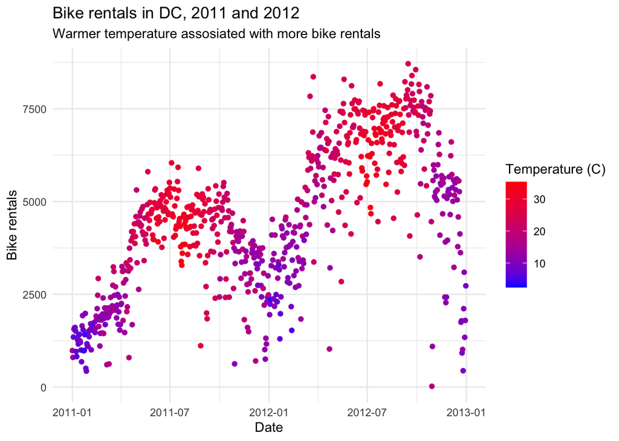

```r
dcbikeshare |>
  ggplot(mapping = aes(x = dteday, y = cnt, color = temp * 41)) +
    geom_point() +
    labs(x = "Date", y = "Bike rentals", color = "Temperature (C)", title = "Bike rentals in DC, 2011 and 2012", subtitle = "Warmer temperature assosiated with more bike rentals") +
  scale_color_gradient(low = "blue", high = "red") +
  theme_minimal()
```

`temp`, `atemp`, `hum`, `windspeed` are `standardised` by a factor of 41, 50, 100 and 67 (as per data description).

```r
dcbikeshare <- dcbikeshare |>
  mutate(temp = temp * 41, atemp = atemp * 50,
         hum = hum * 100, windspeed = windspeed * 67)
```

### Creating a pairs plot refer the formula below

Checking for multicollinearity

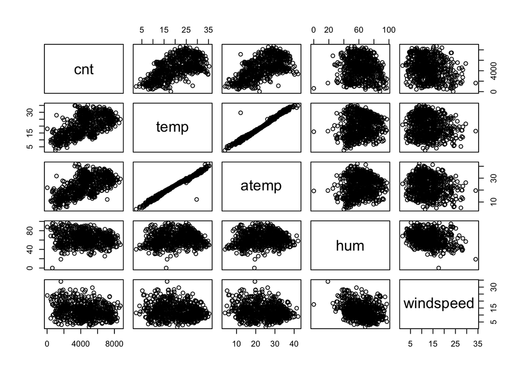

```r
pairs(cnt ~ temp +atemp + hum + windspeed, data = dcbikeshare)
```

We can see a positive correlation between `temp` and `cnt` als between `cnt` and `atemp`, hence collinearity exist between `temp` and `atemp`. Variables `hum` and `windspeed` doesn’t show any strong relationship with response.

### Fitting linear regression model predicting total daily bike rentals from daily temperature

```r
model_temp <- lm(cnt ~ temp, data = dcbikeshare)
summary(model_temp)
```

```
Call:
lm(formula = cnt ~ temp, data = dcbikeshare)

Residuals:
    Min      1Q  Median      3Q     Max
-4615.3 -1134.9  -104.4  1044.3  3737.8

Coefficients:
            Estimate Std. Error t value Pr(>|t|)
(Intercept) 1214.642    161.164   7.537 1.43e-13 ***
temp         161.969      7.444  21.759  < 2e-16 ***
---
Signif. codes:  0 '***' 0.001 '**' 0.01 '*' 0.05 '.' 0.1 ' ' 1

Residual standard error: 1509 on 729 degrees of freedom
Multiple R-squared:  0.3937,    Adjusted R-squared:  0.3929
F-statistic: 473.5 on 1 and 729 DF,  p-value: < 2.2e-16
```

And the obtained R-squared value is 0.3937.

### Fitting the model with rest of the variables

```r
model_full <- lm(cnt ~ season + yr + holiday + workingday + weathersit + temp + atemp +
                   hum + windspeed , data = dcbikeshare)

summary(model_full)
```

```
Call:
lm(formula = cnt ~ season + yr + holiday + workingday + weathersit +
    temp + atemp + hum + windspeed, data = dcbikeshare)

Residuals:
    Min      1Q  Median      3Q     Max
-3667.0  -380.1    69.8   477.3  3339.1

Coefficients:
                               Estimate Std. Error t value Pr(>|t|)
(Intercept)                    2688.149    268.381  10.016  < 2e-16 ***
seasonsummer                   -283.320    100.397  -2.822  0.00490 **
seasonfall                      405.703     96.253   4.215 2.82e-05 ***
seasonwinter                  -1136.181    113.636  -9.998  < 2e-16 ***
yr2012                         2014.146     61.782  32.601  < 2e-16 ***
holidayyes                     -619.306    188.666  -3.283  0.00108 **
workingdayyes                   118.764     67.950   1.748  0.08092 .
weathersitmist                 -424.542     81.346  -5.219 2.36e-07 ***
weathersitlight precipitation -1908.761    207.803  -9.185  < 2e-16 ***
temp                            103.653     34.055   3.044  0.00242 **
atemp                            19.215     30.493   0.630  0.52879
hum                             -13.376      2.958  -4.522 7.17e-06 ***
windspeed                       -40.991      6.496  -6.310 4.87e-10 ***
---
Signif. codes:  0 '***' 0.001 '**' 0.01 '*' 0.05 '.' 0.1 ' ' 1

Residual standard error: 822.5 on 718 degrees of freedom
Multiple R-squared:  0.8227,    Adjusted R-squared:  0.8197
F-statistic: 277.6 on 12 and 718 DF,  p-value: < 2.2e-16
```

Adjusted R-squared obtained is 0.8197 comparing it with previoius model this one is prefferred.

### Splitting the model to training and test dataset

```r
n <- nrow(dcbikeshare)
train_id <- sample(1:n, floor(0.9 * n))  # split 90/10
train <- dcbikeshare[train_id, ]
test <- dcbikeshare[-train_id, ]
```

```r
model_temp_train <- lm(cnt ~ temp, data = train)
model_full_train <- lm(cnt ~ season + yr + holiday + workingday +
                         weathersit + temp + atemp +
                   hum + windspeed , data = train)
```

Extracting prediction from the fitted model with test data

```r
pred_temp <- predict(model_temp_train, newdata = test)
pred_full <- predict(model_full_train, newdata = test)
```

### Computing the RMSE of predicted data

```r
rmse <- function(u, v){
  sqrt(mean((u - v)^2))
}
rmse(test$cnt ,pred_temp)
```

```
[1] 1540.061
```

```r
rmse(test$cnt ,pred_full)
```

```
[1] 1071.146
```

RMSE of `mode_temp` is higher than that of `model_full` hence `model_full` is preferred.